# Séance 2 : Régression Linéaire - COURS

# Introduction

Les modèles de régression linéaire par les Moindres Carrés Ordinaires (MCO) sont des modèles d’estimation de relations entre une variable **endogène** $Y_t$ (ou variable expliquée), et une ou plusieurs variables dites **exogènes** $X_{n,t}$ (ou variables explicatives). C’est l’un des (voire, le) modèles les plus simples en économétrie, mais qui peut être très efficace s’il est bien mené et que les données s’y prêtent.

L’idée fondamentale est simple : lorsque l’on observe une relation entre deux variables — par exemple entre revenu et consommation — on peut estimer la **relation moyenne** qui relie ces variables à partir des données observées. Pour cela, les modèles MCO vont viser à **minimiser l’erreur quadratique**.

La régression linéaire moderne repose sur la formulation suivante :
$$y_t =\beta_0+ \beta_1 x_t + \varepsilon_t$$

Où $y_t$ est appelée la **variable expliquée**, $x_t$ est la **variable explicative**, et $\varepsilon_t$ représente le **terme d’erreur** — c’est-à-dire tout ce que $x_t$ n’explique pas. Si on réécrit l’équation :
$$\varepsilon_t = y_t - \beta_0 - \beta_1 x_t$$

> Le terme d’erreur, c’est ce qui reste une fois qu’on a retiré l’influence de $x_t$. Il ne disparaît jamais complètement : il y a toujours une part d’inexpliqué.

On peut illustrer cela avec un exemple simple : la relation entre la vitesse d’une voiture et sa distance de freinage. *(Pour cet exemple, il ne s’agit pas de séries temporelles : la vitesse et la distance de freinage ne sont pas indexées par le temps.)*

|  | speed | dist |
| --- | --- | --- |
| 1 | 4 | 2 |
| 2 | 4 | 10 |
| 3 | 7 | 4 |
| 4 | 7 | 22 |
| 5 | 8 | 16 |
| 6 | 9 | 10 |

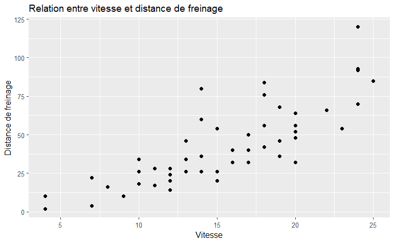

Effectuer une régression linéaire revient à tracer la **droite de régression** qui minimise les écarts avec l’ensemble des points. Cette droite ressemble à une fonction affine $y = ax + b$ :

- $b$ correspond à $\beta_0$ : c’est l’**ordonnée à l’origine**, la valeur prédite quand $x = 0$
- $a$ correspond à $\beta_1$ : c’est la **pente**, l’effet d’une augmentation d’une unité de $x$ sur $y$

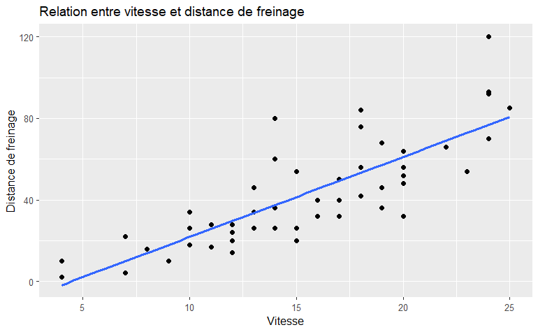

La régression peut être notée comme
$$Dist = \beta_0 + \beta Speed + \varepsilon$$

```
                              reg
Dependent Var.:              dist

Constant         -17.58** (6.758)
speed           3.932*** (0.4155)
_______________ _________________
S.E. type                     IID
Observations                   50
R2                        0.65108
Adj. R2                   0.64381
---
Signif. codes: 0 '***' 0.01 '**' 0.05 '*' 0.1 ' ' 1
```

Ici, l’augmentation de la vitesse d’1 mph (environ 1.6 km/h) provoque une augmentation de la distance de freinage d’environ 4 pieds (environ 1,2 mètres). C’est le sens du coefficient $\beta_1$ : **un chiffre, une interprétation directe**.

`/!\` **Attention: l’interprétation donnée ici est *causale* (“l’augmentation provoque une augmentation…”). Avec une régression de ce type en revanche, on n’a pas estimé un effet causal. Il faudrait donc préférer dire “L’augmentation de la vitesse d’1mph est associé à une augmentation de la distance de freinage d’environ 4 pieds”.**

La droite de régression représente les **valeurs prédites** du modèle. Elles sont généralement notées avec un chapeau. Ici en l’occurence:

$$\hat y_t = \hat\beta_0 + \hat \beta_1
x_t$$

Elle permet aussi d’extrapoler : même au-delà des observations disponibles, on peut estimer ce que serait la distance de freinage à des vitesses plus élevées.

L’écriture du modèle de régression peut donner l’impression que $y_t$ est entièrement expliqué par $x_t$. Dans l’exemple précédent, on pourrait penser que la distance de freinage est entièrement déterminée par la vitesse de la voiture.

**Ce n’est jamais exactement le cas.**

Deux voitures roulant à la même vitesse peuvent avoir des distances de freinage différentes : l’état de la route, la qualité des freins, la masse du véhicule ou encore le temps de réaction du conducteur peuvent également influencer la distance de freinage. Tous ces facteurs supplémentaires ne sont pas observés dans notre modèle — ils sont regroupés dans le **terme d’erreur** $\varepsilon_t$.

> Le terme d’erreur ne représente pas une erreur de mesure. Il représente **tout ce qu’on ne sait pas** : les facteurs invisibles, les chocs imprévisibles, la part irréductible d’aléatoire dans tout phénomène réel.

En économétrie, on modélise ce terme comme une **variable aléatoire** : même si la relation moyenne entre $x_t$ et $y_t$ peut être décrite par une droite, les observations réelles fluctuent autour de cette relation en raison de bruit statistique, des chocs nombreux et imprévisibles mais qui s’annulent en moyenne.

Graphiquement, cela signifie que les points observés ne se situent jamais exactement sur la droite de régression. La zone grisée dans le graphique suivant correspond à un intervalle de confiance autour de la droite de régression — elle représente cette incertitude statistique :

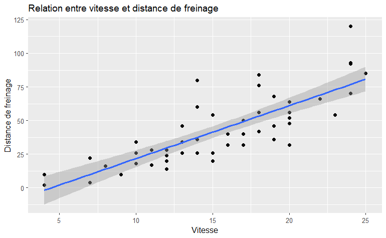

Les écarts entre la droite de régression et les points constituent les **résidus** du modèle. Ce sont ces résidus qu’on cherche à minimiser dans un modèle MCO (Moindres Carrés Ordinaires) : on minimise la somme de leurs carrés.

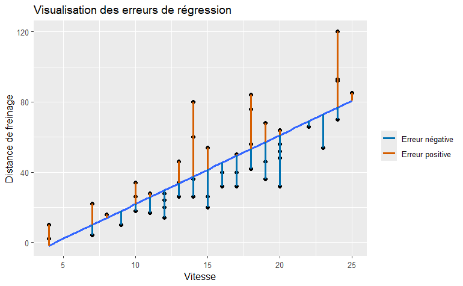

Les résidus représentent la différence entre les valeurs observées ($y_t$) et les **valeurs prédites** par le modèle ($\hat y_t$) :

$$\hat \varepsilon_t = y_t - \hat y_t$$

**Plus les résidus sont petits, mieux le modèle ajuste les données.** C’est exactement ce que minimise la méthode des moindres carrés.

Si on reprend, l’équation de régression peut s’écrire:
$$y_t =\beta_0+ \beta_1 x_t + \varepsilon_t$$
;

et les valeurs prédites par le modèles sont :
$$\hat y_t = \hat\beta_0 + \hat \beta_1 x_t$$

les résidus représentent l’écart entre les valeurs prédites par le modèle et les vraies valeurs observées:
$$\hat \varepsilon_t = y_t - \hat y_t$$

donc on peut remplacer $\hat y_t$ dans l’expression des résidus:
$$\hat
\varepsilon_t = y_t - (\hat\beta_0 + \hat \beta_1 x_t)$$
$$\hat \varepsilon_t = y_t - \hat\beta_0 - \hat
\beta_1 x_t$$

La méthode des MCO va donc avoir pour objectif de trouver des valeurs pour $\hat \beta_0$ et $\hat \beta_1$ qui minimisent les erreurs. Comme les écarts entre $y_t$ et $\hat y$ peuvent être positifs et négatifs, minimiser les résidus simples pourrait les faire s’annuler entre eux. C’est la raison pour laquelle les MCO vont minimiser le carré des résidus.

Dans le cas le plus simple d’une régression linéaire univariée (une seule variable explicative), l’estimation du beta se simplifie en
$$\hat \beta =
\frac{Cov(x,y)}{Var(x)}$$

```
                              reg
Dependent Var.:              dist

Constant         -17.58** (6.758)
speed           3.932*** (0.4155)
_______________ _________________
S.E. type                     IID
Observations                   50
R2                        0.65108
Adj. R2                   0.64381
---
Signif. codes: 0 '***' 0.01 '**' 0.05 '*' 0.1 ' ' 1
[1] 3.932409
```

```
cov(cars$speed, cars$dist) / var(cars$speed)
```

```
[1] 3.932409
```

On a bien le même résultat entre l’estimation avec la fonction intégrée dans R et le calcul à la main.

Aussi, on peut réécrire la formule du beta estimé:

$$\hat \beta =
\frac{Cov(x,y)}{Var(x)}$$

La covariance s’écrit également

$$Cov(x,y) = Cor(x,y) \sigma_x
\sigma_y$$

avec $\sigma_x$ et $\sigma_y$ représentant les écarts types de $x$ et de $y$ respectivement. Les écart-types sont forcément positifs, et la corrélation peut être positive ou négative (comprise entre -1 et 1), donc **le signe du coefficient de régression dans une régression linéaire univarié est nécessairement le même que le signe de la corrélation entre les deux variables**.

Avec le tableau de régressions, d’autres éléments en dehors du coefficient de régression sont présents.

La première chose importante est la **significativité du coefficient**, aussi appelée *p-value* et représentée ici par des `*`. Quand on estime la relation entre `X` et `Y`, le coefficient $\hat\beta$ représente l’impact estimé de $X$ sur $Y$ et est associé à un interval de confiance représentée par l’écart standard ($SE(\hat\beta)$), entre parenthèse à côté du coefficient. Si cet interval de confiance contient la valeur 0, alors le coefficient ne peut pas être statistiquement différent de 0, il n’est donc pas significatif.

La p-value se calcule à partir de la **t-statistique**, calculée de la manière suivante :
$$t =
\frac{\hat \beta}{SE(\hat\beta)}$$
La t-statistique mesure la distance entre le coefficient estimé et zéro, en tenant compte de son incertitude. Plus la valeur absolue de la t-statistique est élevée, moins il est plausible d’obtenir un tel résultat si le vrai coefficient était nul. La p-value traduit cette distance en une probabilité. $t \sim 1.65$ correspond au seuil de significativité à 10%, $t \sim 1.96$ correspond au seuil à 5%, et $t\sim 2.58$ correspond au seuil à 1%.

Par exemple:

```
                                      reg
Dependent Var.:                      dist

Constant        -17.58** [-28.91; -6.244]
speed             3.932*** [3.236; 4.629]
_______________ _________________________
VCOV type                             IID
Observations                           50
R2                                0.65108
Adj. R2                           0.64381
---
Signif. codes: 0 '***' 0.01 '**' 0.05 '*' 0.1 ' ' 1
```

l’interval de confiance à 90% (significativité à 10%) autour du coefficient beta est compris entre 3.236 et 4.629. Autrement dit, une augmentation de la vitesse d’1 mph provoque une augmentation de la distance de freinage de 3.932 pieds, mais ce coefficient est le point médian de l’intervalle de confiance. La distance peut donc augmenter de 3.236 pieds ou 4.629 pieds avec la même “probabilité” (on ne peut pas les distinguer).

```
borne_inferieure = 3.932 - 1.65* 0.4155

borne_superieure = 3.932 + 1.65* 0.4155
```

```
[1] "Borne inférieure =  3.246425"
[1] "Borne supérieure =  4.617575"
```

Les petites différences viennent du fait qu’on a utilisé la valeur 1.65 qui est une approximation (la vraie valeur est plutôt autour de 1.677).

Enfin, le $R^2$ représente la force explicative du modèle, et est souvent décrit comme une mesure de la part des variations de $Y$ que le modèle parvient à expliquer. Il est calculé de la façon suivante:

$$R^2 = 1 - \frac{\sum_i (y_i - \hat
y_i)^2}{\sum_i(y_i - \bar y)^2}$$

C’est en gros l’écart entre les vraies observations et les valeurs prédites (la droite de régression) divisé par l’écart entre chaque observation et les observations moyennes (la dispersion des données). Grossièrement, le $R^2$ se calcule avec les erreurs de la régression divisées par les erreurs si on prédisait seulement la moyenne de $Y$ sans connaître $X$.

Visuellement, plus les observations sont proches de la droite de régressioin, plus le $R^2$ élevé.

**Attention** : un $R^2$ élevé ne signifie pas que le modèle est « bon » dans tous les sens du terme. Il ne prouve ni causalité, ni absence de biais, ni validité économique de la relation. Au contraire, il peut être biaisé par la multicolinéarité dans le modèle. En général, un $R^2$ faible n’est pas un problème, mais un $R^2$ trop haut ($>80\%$) est potentiellement signe d’un problème.

Quand on effectue une régression, particulièrement en séries temporelles, on pose de nombreuses hypothèses sur les résidus (voir Séance 4 des TD). Cependant, on peut violer ces hypothèses par le fait qu’on utilise des “mauvaises” données dans la régression, c’est-à-dire qu’on utilise des données dites “non-stationnaires” (voir Séance 3 des TD).